# Project Report

Praminda M Imaduwa-Gamage(pwi2)

July 25, 2017

### Modeling the Effect of Cigarette Smoking on the Pulmonary Function of Children

### Group: One member group

### 1. Introduction

Reference: http://www.statsci.org/data/general/fev.html  
Nature of data: Research

Forced expiration is a simple but extremely useful pulmonary function test. A spirometry tracing is obtained by having a person inhale to total lung capacity and then exhaling as hard and as completely as possible. These tracings are a very effective way of separating normal ventilatory states from obstructive and restrictive states.

A study entitled the “effect of cigarette smoking on the pulmonary function of children”" by Tager, Weiss, Rosner, and Speizer (1979), and Tager, Weiss, Muno, Rosner, and Speizer (1983) aimed at assessing children’s pulmonary function in the absence or presence of smoking cigarettes, as well as exposure to passive smoke from at least one parent. These papers represent some of the earliest attempts at systematic documentation regarding obvious signs of reduced pulmonary function from smoking and from exposure to second-hand smoke.

In this project, I will use the data from the above mentioned study to investigate a “good” linear regression model that can explain the effect of cigarette smoking on the pulmonary function of children.

#### 1.1. Data Set

```r
fev = read.table('fev.txt', header = TRUE)
```

```
'data.frame':   654 obs. of  6 variables:
 $ ID    : int  301 451 501 642 901 1701 1752 1753 1901 1951 ...
 $ Age   : int  9 8 7 9 9 8 6 6 8 9 ...
 $ FEV   : num  1.71 1.72 1.72 1.56 1.9 ...
 $ Height: num  57 67.5 54.5 53 57 61 58 56 58.5 60 ...
 $ Sex   : Factor w/ 2 levels "Female","Male": 1 1 1 2 2 1 1 1 1 1 ...
 $ Smoker: Factor w/ 2 levels "Current","Non": 2 2 2 2 2 2 2 2 2 2 ...
```

```
  Age   FEV Height    Sex Smoker
1   9 1.708   57.0 Female    Non
2   8 1.724   67.5 Female    Non
3   7 1.720   54.5 Female    Non
4   9 1.558   53.0   Male    Non
5   9 1.895   57.0   Male    Non
6   8 2.336   61.0 Female    Non
```

**Number of observations:** 654  
**Number of numerical response:** 1, FEV (Forced exploratory volume)  
**Number of numerical predictors:** 2, Height & Age  
**Number of categorical predictors:** 2, sex & smoker

### 2. Methods

#### 2.1. **Variable Selection Procedure**

Initial screening for modeling FEV was performed with regsubsets() function in leap R package. Variable selection was conducted using “exhaustive” search.

```r
add_fev_mod = lm(FEV ~., fev)
all_fev_mod = summary(regsubsets(FEV ~., data = fev))
```

Variable Selection

|  | (Intercept) | Age | Height | SexMale | SmokerNon |
| --- | --- | --- | --- | --- | --- |
| 1 | TRUE | FALSE | TRUE | FALSE | FALSE |
| 2 | TRUE | TRUE | TRUE | FALSE | FALSE |
| 3 | TRUE | TRUE | TRUE | TRUE | FALSE |
| 4 | TRUE | TRUE | TRUE | TRUE | TRUE |

Quality Criterion

|  | RSS | BIC | AIC | adjR2 |
| --- | --- | --- | --- | --- |
| 1 | 120.934 | -903.311 | -1099.862 | 0.753 |
| 2 | 114.675 | -931.584 | -1132.618 | 0.766 |
| 3 | 110.648 | -948.480 | -1153.997 | 0.774 |
| 4 | 110.280 | -944.178 | -1154.178 | 0.774 |

Best Quality Criterion

|  | RSS | BIC | AIC | adjR2 |
| --- | --- | --- | --- | --- |
|  | 110.28 | -948.48 | -1154.178 | 0.774 |

Selected Models

|  | RSS | BIC | AIC | adjR2 |
| --- | --- | --- | --- | --- |
|  | 4 | 3 | 4 | 4 |

Decision

|  | (Intercept) | Age | Height | SexMale | SmokerNon |
| --- | --- | --- | --- | --- | --- |
|  | TRUE | TRUE | TRUE | TRUE | TRUE |

#### 2.2. **Models**

Variable selection procedure was used as a guild line for model development. Three quality criterion (RSS, AIC, adjR2) suggest to use all four predictors in the additive model. In the model building process, attempts were made to build a simple model that obey the linear regression assumptions. The presented models include one numerical variable, interaction between one numerical variable and one categorical variable, full additive model, additive variables with one square variable, and transformation of the response variable. Four models are gender-free models while three models include sex as a variable.

Gender-free models

$y = \beta_0 + \beta_1 x_1$  
$y = \beta_0 + \beta_2 x_2$  
$y = \beta_0 + \beta_1 x_1 + \beta_4 x_4 + \gamma x_1x_4$  
$y = \beta_0 + \beta_2 x_2 + \beta_4 x_4 + \gamma x_2x_4$

Full-models

$y = \beta_0 + \beta_1 x_1 + \beta_2 x_2 + \beta_3 x_3 + \beta_4 x_4$
$y = \beta_0 + \beta_1 x_1 + \beta_2 x_2 + \beta_3 x_3 + \beta_4 x_4 + \gamma_1 x_1^2$$
$log(y) = \beta_0 + \beta_1 x_1 + \beta_2 x_2 + \beta_3 x_3 + \beta_4 x_4 + \gamma_1 x_1^2 + \gamma_2 x_2^2 + \delta x_1x_4$

Where  
$x_1:$ Height, $x_2:$ Age, $x_3:$ Sex, $x_4:$ Smoke

R_Codes:

```r
model_1 = lm(FEV ~ Height, fev)
model_2 = lm(FEV ~ Age, fev)
model_3 = lm(FEV ~ Height * Smoker, fev)
model_4 = lm(FEV ~ Age * Smoker, fev)
model_5 = lm(FEV ~ ., fev)
model_6 = lm(FEV ~. + I(Height^2), fev)
model_7 = lm(log(FEV) ~. + I(Height^2) + I(Age^2) + Smoker * Height, fev)
```

Model_7 with a subset of original data:

```r
cd_model_7 = cooks.distance(model_7)
model_7_fix = lm(log(FEV) ~. + I(Height^2) + I(Age^2) + Smoker * Height,
             data = fev,
             subset = cd_model_7 <= 4/length(cd_model_7))
```

#### 2.3. **Model Diagnostics**

Regression model diagnostics were carried out with Breusch-Pagan (BP test) and Shapiro-Wilk (SW test) tests to check heteroskedasticity and normality of residuals of linear regression models, respectively. The size-effects of models were evaluated by leave one out cross validation RMSE (LOOCV_rmse) and ajusted R squared (adjR2) measures. Model’s tendency to overfit data was accessed with equation

$$CV(RMSE) = \sqrt{1/n \sum_{i=1}^{n} [e_i/(1 - h_i)]^2}$$
where $h_i$ are the leverages, $e_i$ are the residuals, and $n$ is number of observation. BP test and SW test were performed using bptest() and shapiro.test() in functions available in lmtest and stats R packages. Adjusted $R^2$ was reported with summary() function in R base package. get_loocv_rmse() was written to calculate LOOCV_rmse values.

Residual vs fitted plots and variance inflation factor (vif() function in faraway R package) were also reported to access constant varience of residuals and multicolinearity among variables, respectively.

#### 2.4. **Simulations**

To access the significance of $\hat\beta^_3$, simulation study was done with model_7_fix as follows:

```r
n = 5000
co = coef(model_7_fix)
co = c(co[1], co[3], co[2], co[4:8])

beta0 = co[1]
beta1 = co[2]
beta2 = co[3]
beta3 = co[4]
beta4 = co[5]
gamma1 = co[6]
gamma2 = co[7]
delta = co[8]

cd_model_7 = cooks.distance(model_7)
fev_sim = fev[cd_model_7 <= 4/length(cd_model_7), ]

x1 = fev_sim$Height
x2 = fev_sim$Age
x3 = as.numeric(fev_sim$Sex)
x4 = as.numeric(fev_sim$Smoker)

pval = rep(0, n)
set.seed(19781014)

for (i in 1: n){

    error = rnorm(length(fev_sim$Height), mean = mean(log(fev_sim$FEV)), sd = sd(log(fev_sim$FEV)))

   logy = beta0 + beta1 * x1 + beta2 * x2 + beta3 * x3 + beta4 * x4 +
     gamma1 * x1^2 + gamma2 * x2^2  +  delta * x1 * x4 + error

     model_sim = lm(logy ~ x1 + x2 + x3 + x4 + I(x1^2) + I(x2^2) + x1 * x4)
      pval[i] = coef(summary(model_sim))['x3', 'Pr(>|t|)']

}
```

### 3. Results

#### 3.1. **Distribution, Central Tendency, and Spread**

##### (a) Distributions

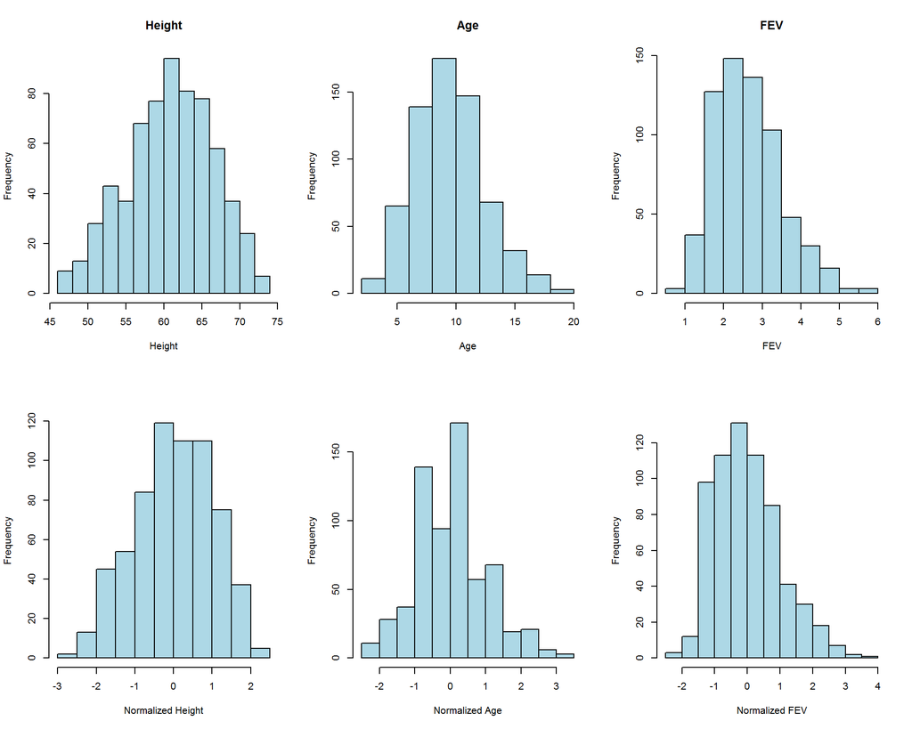

Number of non smokers:589  
Number of smokers: 65  
Number of male: 336  
Number of female:318

##### (b) Central Tendency

| Variable | Mean | Median |
| --- | --- | --- |
| FEV | 2.637 | 2.547 |
| Height | 61.144 | 61.500 |
| Age | 9.931 | 10.000 |

##### (c) Spread

| Variable | Variance | St.Deviation | IQR | Minimum | Maximum |
| --- | --- | --- | --- | --- | --- |
| FEV | 0.752 | 0.867 | 1.137 | 0.791 | 5.793 |
| Height | 32.530 | 5.704 | 8.500 | 46.000 | 74.000 |
| Age | 8.726 | 2.954 | 4.000 | 3.000 | 19.000 |

#### 3.2. **Correlations**

##### **Correlograms**

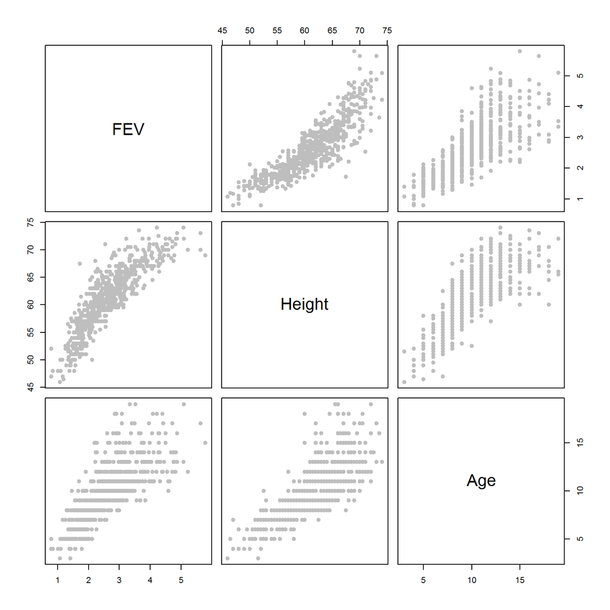

#### 3.3. **Model_1 and Model_2: Trends of FEV**

##### **Model_1**

$y = \beta_0 + \beta_1 x_1$

$y = -5.43268 + 0.13198 x_1$

##### **Model_2**

$y = \beta_0 + \beta_2 x_2$

$y = 0.43165 + 0.22204 x_1$

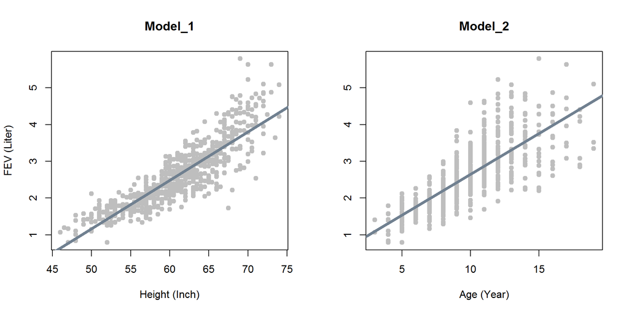

#### 3.4. **Model_3 and Model_4: Trends of FEV: Smokers and Non-Smokers**

##### **Model_3**

$y = \beta_0 + \beta_1 x_1 + \beta_4 x_4 + \gamma x_1x_4$

$y = -7.40165 + 0.16191 x_1 + 2.03678 x_4 - 0.03106 x_1 x_4$

##### **Model_4**

$y = \beta_0 + \beta_2 x_2 + \beta_4 x_4 + \gamma x_2x_4$

$y = 2.19697 + 0.07986 x_1 - 1.94357 x_4 + 0.1627 x_2 x_4$

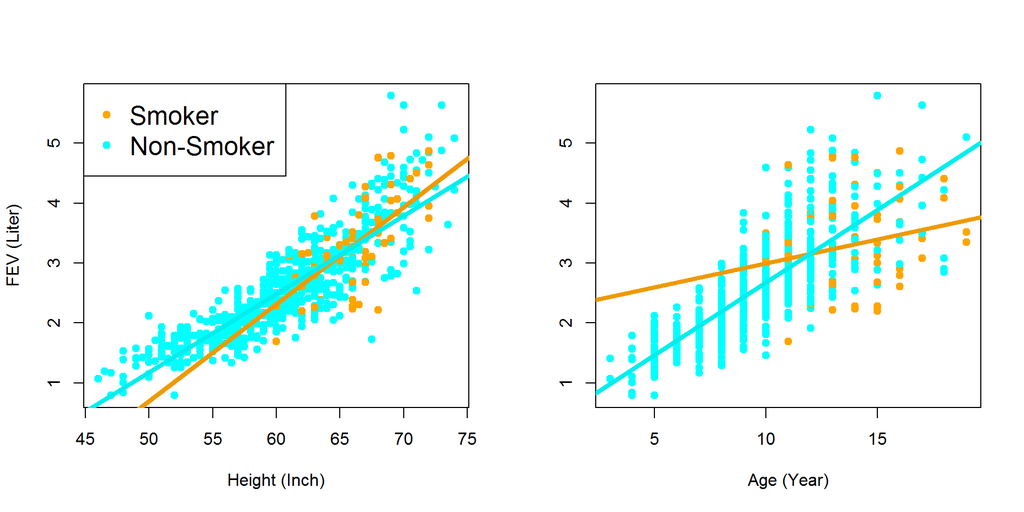

#### 3.5. **Model_5, Model_6, Model_7: Search for Good-Models**

##### **Model_5**

$y = \beta_0 + \beta_1 x_1 + \beta_2 x_2 + \beta_3 x_3 + \beta_4 x_4$

$y = -4.54422 + 0.1042 x_1 + 0.06551 x_2+ 0.1571 x_3 + 0.08725 x_4$

##### **Model_6**

$y = \beta_0 + \beta_1 x_1 + \beta_2 x_2 + \beta_3 x_3 + \beta_4 x_4 + \gamma_1 x_1^2$

$y = 6.76137 - 0.27423 x_1 + 0.06946 x_2 + 0.09454 x_3 + 0.13321 x_4 + 0.00313 x_1^2$

##### **Model_7**

$log(y) = \beta_0 + \beta_1 x_1 + \beta_2 x_2 + \beta_3 x_3 + \beta_4 x_4 + \gamma_1 x_1^2 + \gamma_2 x_2^2 + \delta x_1x_4$

$log(y) = -2.71167 + 0.06303 x_1 + 0.02524 x_2 + 0.03163 x_3 + 0.2545 x_4 - 0.00014 x_1^2 - 0.00008 x_2^2 - 0.0032 x_1x_4$

##### **Model_7_fix**

$log(y) = -2.17065 + 0.04752 x_1 + 0.01227 x_2 + 0.02069 x_3 + 0.20801 x_4 - 0.00001 x_1^2 + 0.00048 x_2^2 - 0.00245 x_1x_4$

### **Winner**

##### **Model_8**

$log(y) = -1.99861 + 0.04079 x_1 + 0.01201 x_2 + 0.25491 x_4 + 0.00005 x_1^2 + 0.00046 x_2^2 - 0.00309 x_1x_4$

#### 3.6. **Model Diagnostics**

|  | Model_1 | Model_2 | Model_3 | Model_4 | Model_5 |
| --- | --- | --- | --- | --- | --- |
| Parameters | 2 | 2 | 4 | 4 | 5 |
| BP test | Reject | Reject | Reject | Reject | Reject |
| SW test | Reject | Reject | Reject | Reject | Reject |
| Loocv_rmse | 0.432 | 0.569 | 0.432 | 0.557 | 0.415 |
| AdjR2 | 0.753 | 0.572 | 0.754 | 0.592 | 0.774 |

Multicolinearity

|  | Age | Height | Sex | Smoker |
| --- | --- | --- | --- | --- |
| VIF | 3.019 | 2.83 | 1.06 | 1.21 |

#### 3.7. **Developing a Good-Model**

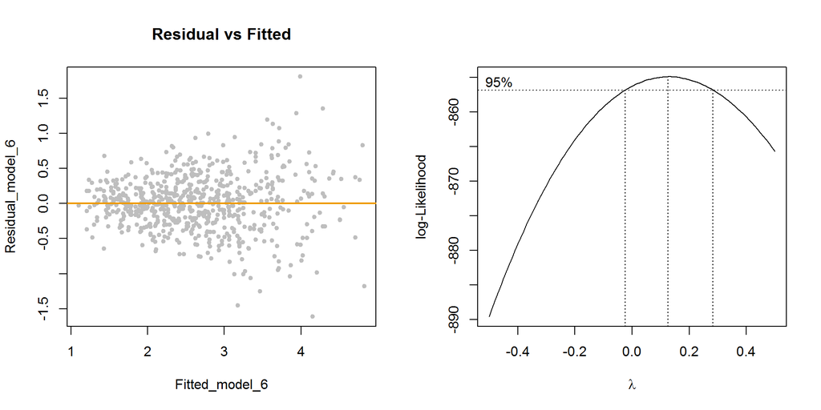

**$\alpha$ = 0.01**

|  | Model_6 | Model_7 |
| --- | --- | --- |
| Parameters | 6 | 8 |
| BP test | Reject | Fail to Reject |
| SW test | Reject | Reject |
| Loocv_rmse | 0.398 | 0.147 |
| AdjR2 | 0.792 | 0.809 |

**$\alpha$ = 0.0099**

|  | Model_7_fix |
| --- | --- |
| Parameters | 8 |
| BP test | Fail to Reject |
| SW test | Fail to Reject |
| Loocv_rmse | 0.129 |
| AdjR2 | 0.837 |

**Model_8: Winner**

**$\alpha = 0.01$**

|  | Model_8 |
| --- | --- |
| p | 7 |
| bp | Fail to Reject |
| sw | Fail to Reject |
| rmse | 0.129 |
| adjr | 0.837 |

### 4. Discussion

#### 4.1. **Distribution, Central Tendency, and Spread**

Histograms in section 3.1 show the distribution of height, Age, and FEV of the participents in the study. Mean and medin of height, age, and FEV are given in table (b) in section 3.1. The Histogram of height exhibits almost an normal distribution. The normalized histogram of height further confirm the normality of height distributions. Histogram of the age appears to be slightly skewed to the right. However, the normalized histogram exhibits two relative peaks; one to the left and one to the right of zero. Histograms of FEV and its normalized values are slightly right sewed (note that mean of FEV is greater than the median in table (b)). Table (c) summarizes the spread of height, age, and FEV.

#### 4.2. **Correlations**

Correlation plots in section 3.2 show that FEV has positive correlations with both height and age variables. FEV appears to increase somewhat non linearly with height. In section 3.6, multicolinearity among age, height, sex, and smoker variables are shown. Variance inflation factors were found to be at acceptable level (below 5) for all the variables. Hence, multicolinearity is not a concern in the model development process.

#### 4.3. **Gender-Free models**

1. **Model_1 and Model_2: Trends of FEV**

coefficients of predictors in model_1 and model_2 are summerized in section 3.3. One inch increase in height will increase the mean FEV by 132 ml. Aging also increases person’s FEV. Aging by one year will increase the mean FEV by 222 ml.

2. **Model_3 and Model_4: Trends of FEV in Smokers and Non-Smokers**

Coefficients of predictors in model_3 and model_4 are summarized in section 3.4. Mean increase FEV of children exposed to passive smoking is 162 mL and that of children with non-smoking parents is 131 mL for one inch growth in chidren’s height. Hence, children exposed to passive smoking tend to forcefully exhale 31 mL more air than children who do not exposed to passive smoking. This can be a sign of obstruction of the lung functions of children who exposed to passive smoking by their parents.

Mean increase FEV of children exposed to passive smoking is 80 mL and that of children with non-smoking parents is 243 mL by one year of aging. Hence, children exposed to passive smoking tend to forcefully exhale 163 mL less air than the children who do not exposed to passive smoking with aging by one year.

#### 4.4. **Developing a good-model**

Model_5, Model_6, and Model_7 are attempts in search for a good model. Here, good model is defined as fail to reject status for BP and SW test, low value for small value for loocv_rmse, and high value for the adjusted $R^2$ (AdjR2). Number of parameters are tried to keep below 10.

Diagnostics of Model_7_fix is shown in section 3.7. With the removal of influential 33 points, model_7 did not fail the normality and constant variance assumptions at $\alpha = 0.0099$. loocv_rmse value further decreased and the adjusted $R^2$ also increased. Hence, model_7 can be considered as a good regression model to explain and predict variations in FEV.

#### 4.5. **Interpretation of model parameters**

Model_7 has two categorical predictors. $x_3$ for Sex which take two values (female = 0 and male = 1) and $x_4$ for Smoker that takes two values (current = 0 and non = 1). The model can be reduced for different categories as follows.

1. Smoking parents, female:

   $log(y_1) = \beta_0 + \beta_1x_1 + \beta_2x_2 + \gamma_1x_1^2 + \gamma_2x_2^2$ $y_1 = exp(-2.17065 + 0.04752 x_1 + 0.01227 x_2 - 0.00001 x_1^2 + 0.00048 x_2^2)$
2. Smoking parents, male:

   $log(y_2) = \beta_0 + \beta_3 + \beta_1x_1 + \beta_2x_2 + \gamma_1 x_1^2 + \gamma_2 x_2^2$ $y_2 = exp(-2.14996 + 0.04752 x_1 + 0.01227 x_2 - 0.00001 x_1^2 + 0.00048 x_2^2)$  
   $log(y_2) = \beta_3 + log(y_1)$  
   $y_2/y_1 = exp(\beta_3)$  
   $y_2/y_1 \approx exp(\hat\beta_3)$  
   $y_2/y_1 \approx 1.0209$

Hence, mean FEV for a male with smoking parents can be predicted from mean FEV for a female with smoking parents.

3. Non-smoking parents, female

   $log(y_3) = \beta_0 + \beta_4 + (\beta_1 + \delta)x_1 + \beta_2x_2 + \gamma_1x_1^2 + \gamma_2x_2^2$ $y_3 = exp(-1.96264 + 0.04507 x_1 + 0.01227 x_2 - 0.00001 x_1^2 + 0.00048 x_2^2)$
4. Non-smoking parents, male

   $log(y_4) = \beta_0 + \beta_3 + \beta_4 + (\beta_1 + \delta)x_1 + \beta_2x_2 + \gamma_1x_1^2 + \gamma_2x_2^2$ $y_4 = exp(-1.94195 + 0.04507 x_1 + 0.01227 x_2 - 0.00001 x_1^2 + 0.00048 x_2^2)$  
   $y_4/y_3 = exp(\beta_3)$  
   $y_4/y_3 \approx exp(\hat\beta_3)$  
   $y_4/y_3 \approx 1.0209$

From (b) and (d):

$y_2/y_1 = y_4/y_3 \approx 1.0209$  
$y_2/y_4$ or $y_1/y_3$ gives the mean FEV ratio between children with smoking and non-smoking parents, and this ratio is independent of gender of the child.

**Significance of $\hat\beta_3$**

```r
alpha = 0.0099
pval_test = 100 * (1 -  sum(pval < alpha)/length(pval))
```

$log(y) = -1.99861 + 0.04079 x_1 + 0.01201 x_2 + 0.25491 x_4 + 0.00005 x_1^2 + 0.00046 x_2^2 - 0.00309 x_1x_4$

### 5. Appendix

#### Code for Variable Selection Procedure

```r
# INITIAL sELECTION PROCEDURE OF PREDICTORS
model_selection <- function (initial_model, selection_procedure) {

sp = selection_procedure
n = length(resid(initial_model))
p = length(coef(initial_model))
all_fev_mod_aic = n * log(sp$rss / n)  + 2 * (2:p)

result_table =
  data.frame(RSS = sp$rss
           , BIC = sp$bic
           , AIC = all_fev_mod_aic
           , adjR2 = sp$adjr2)

list(
result_table = result_table,
#Best_values: #Minimum values, maximum adjRsquared
bestCriterion =
  c(
  sapply(result_table[, -4], min)
  , sapply(result_table, max)['adjR2']),
#Model-selections
selections =
  c(
  sapply(result_table[, -4], which.min)
  , sapply(result_table, which.max)['adjR2']),
good_model =
  all_fev_mod$which[which.max(all_fev_mod$adjr2),]
)

}
```

#### Codes for model diagnostics

```r
get_bp_decision = function(model, alpha) {
  decide = unname(bptest(model)$p.value < alpha)
  ifelse(decide, "Reject", "Fail to Reject")
}

get_loocv_rmse = function(model) {
  round(sqrt(mean((resid(model) / (1 - hatvalues(model))) ^ 2)), 3)
}


get_sw_decision = function(model, alpha) {
  decide = unname(shapiro.test(resid(model))$p.value < alpha)
  ifelse(decide, "Reject", "Fail to Reject")
}

get_num_params = function(model) {
  length(coef(model))
}

get_adj_r2 = function(model) {
  round(summary(model)$adj.r.squared, 3)
}
```

```r
get_parameter <- function(model){

beta_0 = coef(model)[1]
beta_1 = coef(model)[2]

int_nonsmoker = beta_0 + coef(model)[3]
slope_nonsmoker = beta_1 + coef(model)[4]

list(beta_0 = beta_0
    , beta_1 = beta_1
    , int_nonsmoker = int_nonsmoker
    , slope_nonsmoker = slope_nonsmoker )

}
```

```r
diagnostics <- function (model, alpha) {
  list(
    p = get_num_params(model)
    , bp = get_bp_decision(model, alpha)
    , sw = get_sw_decision(model, alpha)
    , rmse = get_loocv_rmse(model)
    , adjr = get_adj_r2(model)
  )
}
```

```r
alpha = 0.05
model_1_diag = diagnostics(model = model_1, alpha)
model_2_diag = diagnostics(model = model_2, alpha)
model_3_diag = diagnostics(model = model_3, alpha)
model_4_diag = diagnostics(model = model_4, alpha)
model_5_diag = diagnostics(model = model_5, alpha)
model_6_diag = diagnostics(model = model_6, alpha)
model_7_diag = diagnostics(model = model_7, alpha)

kable(data.frame(
    Model_1 = c(unlist(model_1_diag))
  , Model_2 = c(unlist(model_2_diag))
  , Model_3 = c(unlist(model_3_diag))
  , Model_4 = c(unlist(model_4_diag))
  , Model_5 = c(unlist(model_5_diag))
           , row.names = c("Parameters", "BP test", "SW test", "Loocv_rmse", "AdjR2"))
)
```